# Problem Set 1

Due date: Wednesday, 11 September

**Note**

Make sure to render your Quarto document before you submit it. Make sure to address all errors that pop up.

```r
library(skimr)
library(janitor)
library(tidyverse)
```

Please upload your completed assignment to the ELMs course site (under the assignments menu) and to your class Github repository. You need to upload both your Quarto document (with R code, as needed) and its rendered output (either as a PDF or HTML file).

**Total points: 25**

**Note**

To complete this problem set, you will need access to the `polisciols` R package. This package is not published on CRAN[^1], so you will need to install it using the following code:

```r
install.packages("devtools")

devtools::install_github("hgoers/polisciols")
```

```r
install.packages("devtools")

devtools::install_github("hgoers/polisciols")
```

Remember, you only need to do this once on your computer. Run this in the console. Do not include it in your Quarto document.

The [American National Election Studies](https://electionstudies.org/) surveys a representative sample of US voters prior to and following each US Presidential Election. We will use their survey from the last US Presidential Election (held in 2020) to learn more about US voters.

**Tip**

The `nes` data set in the `polsciols` R package provides you with a selection of the hundreds of questions the ANES asked of all 8,280 respondents to the 2020 survey. Each row provides data for one respondent.

## Question 1

Prior to the 2020 US Presidential Election, the ANES asked respondents their highest level of school completed or highest degree received.

### Part A

*Points: 2*

**Note**

2/2

What was the most common highest level of education obtained by respondents? What was the least common? *Use the `education` variable from the `nes` data set to answer these questions.*

```r
library(polisciols)
skim(nes$education)
```

What was the most common highest level of education obtained by respondents? What was the least common? *Use the `education` variable from the `nes` data set to answer these questions.*

```
library(tidyverse)
library(polisciols)
library(skimr)
library(janitor)
skim(nes$education)
```

Data summary

| Name | nes$education |
| --- | --- |
| Number of rows | 8280 |
| Number of columns | 1 |
| _______________________ |  |
| Column type frequency: |  |
| factor | 1 |
| ________________________ |  |
| Group variables | None |

**Variable type: factor**

| skim_variable | n_missing | complete_rate | ordered | n_unique | top_counts |
| --- | --- | --- | --- | --- | --- |
| data | 0 | 1 | TRUE | 8 | Som: 2790, Bac: 2055, Gra: 1592, Hig: 1336 |

```
#or
tabyl(nes, education)
```

```
#or
tabyl(nes, education)
```

```
                                   education    n      percent
                                     Refused   33 0.0039855072
                                  Don't know    1 0.0001207729
                                        <NA>   97 0.0117149758
            Less than high school credential  376 0.0454106280
                      High school credential 1336 0.1613526570
 Some post-high school, no bachelor’s degree 2790 0.3369565217
                           Bachelor’s degree 2055 0.2481884058
                             Graduate degree 1592 0.1922705314
```

**Most frequent**: Some post-high school, no bachelor’s degree (2790)

**Least frequent**: Less than high school credential (376)

Part B

*Points: 2*

**Note**

2/2

Describe the distribution of the total number of respondents that obtained each highest level of education. Include a plot of those counts.

```
ggplot(nes, aes(y = education)) +
  geom_bar() +
  theme_minimal()
```

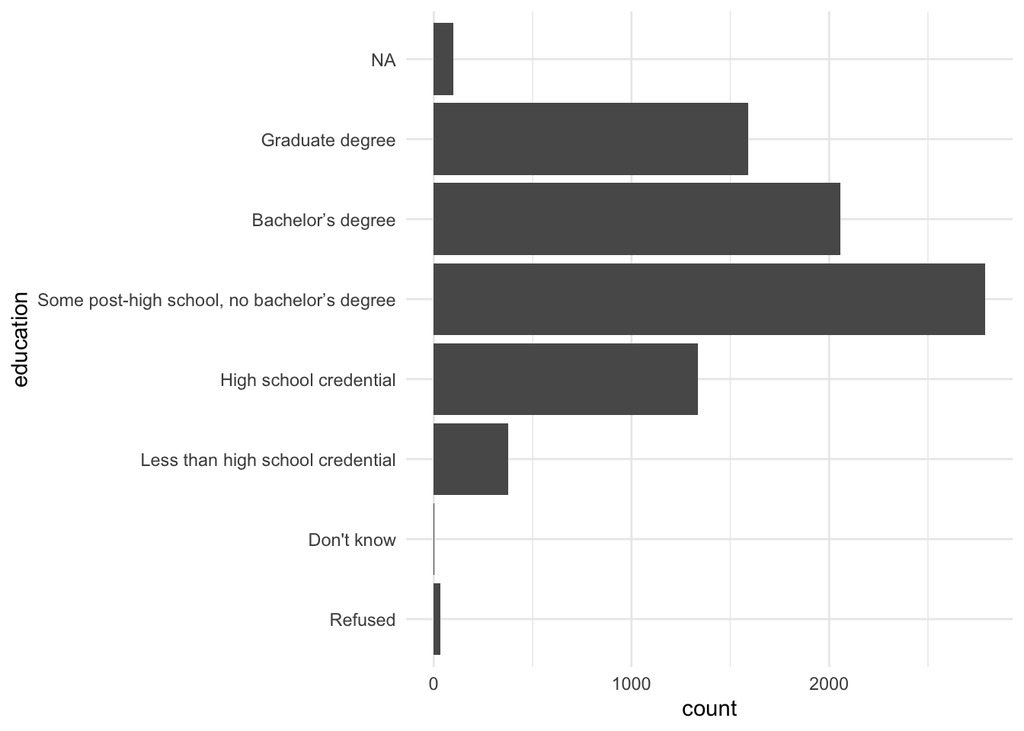

Describe the distribution of the total number of respondents that obtained each highest level of education. Include a plot of those counts.

```
ggplot(nes, aes(y = education)) +
  geom_bar() +
  theme_minimal()
```

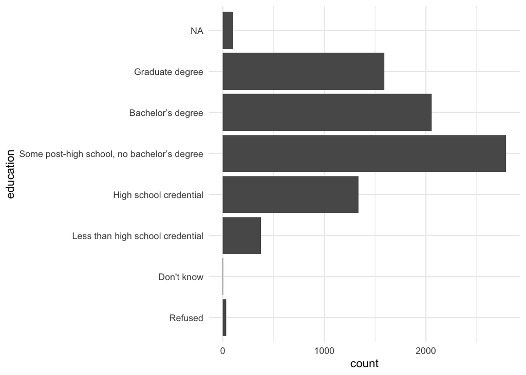

[figure not shown]

Excluding NA, Don’t know, and Refused, this is a fairly **normal distribution**.

Question 2

The ANES also asked each respondent how often they pay attention to what is going on in government and politics. Let’s use these responses to learn more about how much attention US voters pay to politics ahead of a Presidential election.

Part A

*Points: 2*

**Note**

2/2

How often did individuals pay attention to what was going on in government and politics? What was the most popular level of attention? What was the least? *Use the `attention_to_politics` variable from the `nes` data set to answer these questions.*

skim(nes$attention_to_politics)

```
skim(nes$attention_to_politics)
```

How often did individuals pay attention to what was going on in government and politics? What was the most popular level of attention? What was the least? *Use the `attention_to_politics` variable from the `nes` data set to answer these questions.*

skim(nes$attention_to_politics)

```
skim(nes$attention_to_politics)
```

Data summary

| Name | nes$attention_to_politics |
| --- | --- |
| Number of rows | 8280 |
| Number of columns | 1 |
| _______________________ |  |
| Column type frequency: |  |
| factor | 1 |
| ________________________ |  |
| Group variables | None |

**Variable type: factor**

| skim_variable | n_missing | complete_rate | ordered | n_unique | top_counts |
| --- | --- | --- | --- | --- | --- |
| data | 0 | 1 | TRUE | 6 | Mos: 3313, Alw: 1942, Abo: 1587, Som: 1360 |

```
#or
tabyl(nes, attention_to_politics)
```

```
#or
tabyl(nes, attention_to_politics)
```

```
 attention_to_politics    n      percent
               Refused    1 0.0001207729
                Always 1942 0.2345410628
      Most of the time 3313 0.4001207729
   About half the time 1587 0.1916666667
      Some of the time 1360 0.1642512077
                 Never   77 0.0092995169
```

Around 99% of respondents paid at least *some* attention to politics in 2020.

**Most frequent:** Most of the time (3313)

**Least frequent:** Never (77)

Part B

*Points: 3*

**Note**

3/3

Describe the distribution of the total number of respondents who provided each answer to this question. Does this distribution indicate that individuals tend to pay very little, a moderate, or a lot of attention to politics prior to a US Presidential Election? Include a plot of these counts in your answer.

```
ggplot(nes, aes(x = attention_to_politics)) +
  geom_bar() +
  theme_minimal()
```

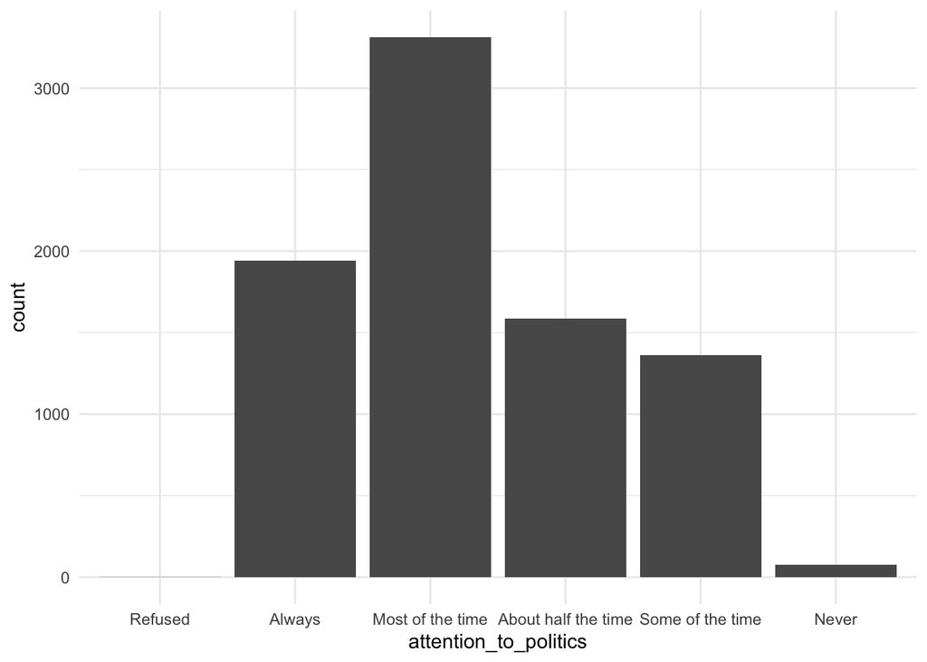

Describe the distribution of the total number of respondents who provided each answer to this question. Does this distribution indicate that individuals tend to pay very little, a moderate, or a lot of attention to politics prior to a US Presidential Election? Include a plot of these counts in your answer.

```
ggplot(nes, aes(x = attention_to_politics)) +
  geom_bar() +
  theme_minimal()
```

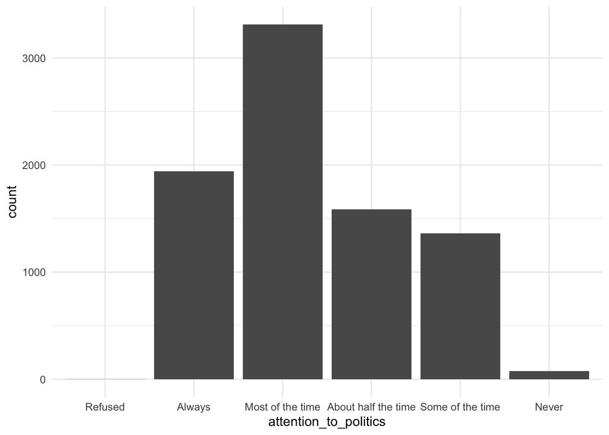

[figure not shown]

This is a **right-skewed distribution**, indicating that most individuals pay a moderate amount of attention to politics, leaning towards a lot.

Question 3

Examine the following vector of (fake) student IQ test scores:

```
iq <- c(
  145, 139, 126, 122, 125, 130, 96, 110, 118, 118, 101, 142, 134, 124, 112, 109,
  134, 113, 81, 113, 123, 94, 100, 136, 109, 131, 117, 110, 127, 124, 106, 124,
  115, 133, 116, 102, 127, 117, 109, 137, 117, 90, 103, 114, 139, 101, 122, 105,
  97, 89, 102, 108, 110, 128, 114, 112, 114, 102, 82, 101
)
```

```
iq <- c(
  145, 139, 126, 122, 125, 130, 96, 110, 118, 118, 101, 142, 134, 124, 112, 109,
  134, 113, 81, 113, 123, 94, 100, 136, 109, 131, 117, 110, 127, 124, 106, 124,
  115, 133, 116, 102, 127, 117, 109, 137, 117, 90, 103, 114, 139, 101, 122, 105,
  97, 89, 102, 108, 110, 128, 114, 112, 114, 102, 82, 101
)
```

Part A

*Points: 3*

**Note**

3/3

Find the five-number summary, mean, and standard deviation for these data. Do you think any of these students might be outliers in this distribution? If so, what IQ test score did they get and how do you know?

```
skim(iq)
```

Find the five-number summary, mean, and standard deviation for these data. Do you think any of these students might be outliers in this distribution? If so, what IQ test score did they get and how do you know?

```
skim(iq)
```

Data summary

| Name | iq |
| --- | --- |
| Number of rows | 60 |
| Number of columns | 1 |
| _______________________ |  |
| Column type frequency: |  |
| numeric | 1 |
| ________________________ |  |
| Group variables | None |

**Variable type: numeric**

| skim_variable | n_missing | complete_rate | mean | sd | p0 | p25 | p50 | p75 | p100 | hist |
| --- | --- | --- | --- | --- | --- | --- | --- | --- | --- | --- |
| data | 0 | 1 | 114.98 | 14.8 | 81 | 104.5 | 114 | 125.25 | 145 | ▂▅▇▅▃ |

There are no outliers in this distribution. First, I determined the Interquartile range by subtracting Q1, or p25, from Q3, or p75. Q3 - Q1 = 125 - 104 = 21.

Second, I subtracted and added 1.5IQR from Q1 and Q3 respectively. These determined the lower and upper fences of my dataset. Here is how I calculated both values:  
Q1 - 1.5IQR = 104 - 31.5 = 72.5 (lower fence)  
Q3 + 1.5 IQR = 125 + 31.5 = 156.5 (upper fence)

No value is below or above either limitation, meaning there are no outliers in this dataset.

```
ggplot(tibble(iq = iq), aes(x=iq)) +
  geom_boxplot()
```

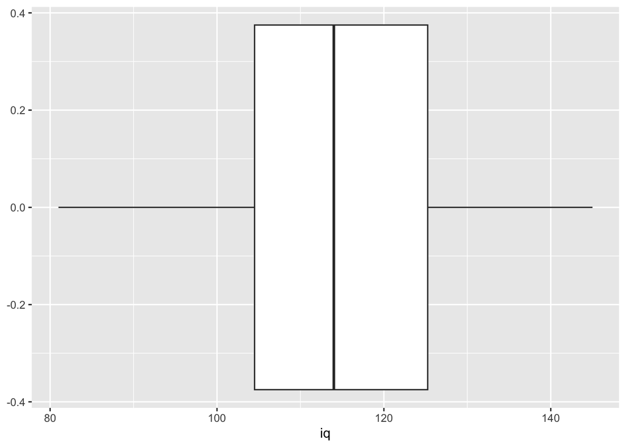

Part B

*Points: 3*

**Note**

3/3

In large populations, IQ test scores are standardized to have a mean of 100 and a standard deviation of 15. In what way does the distribution among these students differ from the overall population? Do not use the words and phrases “mean” or “standard deviation” in your answer.

**Answer:** These students do not differ too differently, at least in terms of *spread*, from a standardized large population. However, the average iq for this group of students is 14 points higher than that of a standardized population.

Question 4

*Points: 4*

**Note**

4/4

The ANES collects information about each respondent’s demographics, including their race, age, household income, and party affiliation. Provide the “type” (categorical or continuous) of variable each of those demographic characteristics represents.

**Race**: Categorical  
**Age:** Continuous *or* Categorical/Ordinal (if binned)  
**Household Income:** Continuous *or* Categorical/Ordinal (if binned)  
**Party affiliation:** Categorical

Question 5

The ANES also asked respondents prior to the election to rate Joe Biden and Donald Trump on a scale from 0 to 100.

Part A

*Points: 3*

**Note**

3/3

Plot all respondents’ answers to these two questions on a single density plot. There are several peaks in these distributions. What do these peaks have in common? What might they suggest about how people answer questions that ask them to provide a single number along a large range?

```
ggplot(data = nes, mapping = aes( )) +
  geom_density( mapping = aes(x = therm_biden), color = "blue" ) +
  geom_density( mapping = aes(x = therm_trump), color = "red") +
  theme_minimal() +
  labs(
    title = "Feeling Thermometer Towards Biden/Trump in 2020",
    x = "Thermometer Score",
    y = "Density")
```

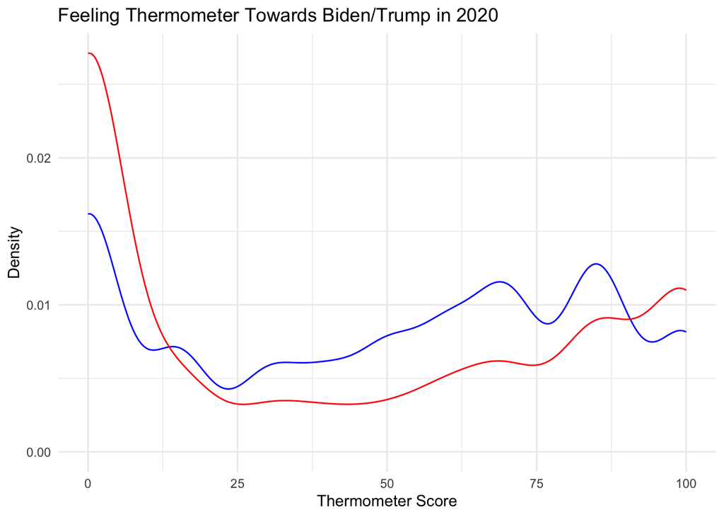

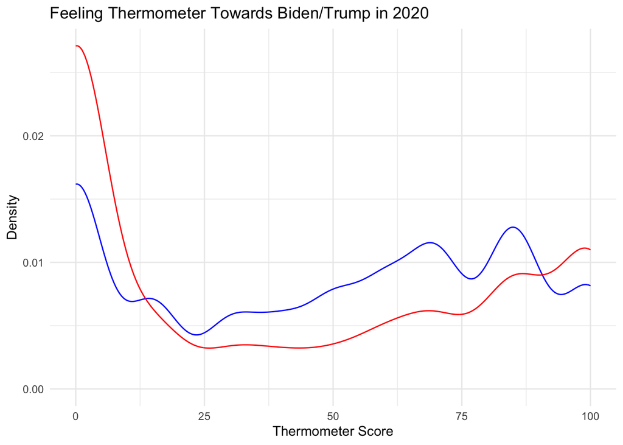

Blue = Therm_Biden  
Red = Therm_Trump

The peaks for both candidates are highly concentrated at both ends of the spectrum, most markedly so around the 0-15 range. This indicates that attitudes towards candidates are highly polarized and negative. These findings suggest that people will are more likely to choose numbers on the ends of a suggested range.

Part B

*Points: 3*

**Note**

3/3

President Biden won this election. Would you predict this outcome from the way this representative sample responded to these questions? Provide a brief description of the reasoning behind your answer.

I would have predicted Biden to win for two reasons. First, it is obvious that negative feelings towards Trump heavily outweighed negative feelings towards Biden. Although Trump performed fairly better than Biden in the 90-100 range, it does not make up for the significant difference in voters entirely opposed to Trump. Secondly, Biden fared better than Trump in terms of density in the 25-90 range, meaning he may have appealled to more voters drawn between the two candidates.

Footnotes

[^1]: The [Comprehensive R Archive Network (CRAN)](https://cran.r-project.org/) hosts many R packages that can be installed easily using the familiar `install.packages()` function. These packages have gone through a comprehensive quality assurance process. I wrote `polisciols` for this class and will update it regularly. I, therefore, will not host it through CRAN: the quality assurance process takes too long to be practical for our weekly schedule. Instead, you are downloading it directly from its Github repository.